# Final_Project_TidyBiology

### `Looking at the data set`

For my project, I am using the Brain RNAseq data set produced by Zhang et al and available at brainrnaseq.org

A glimpse of the data is visible below. The dataset has 15041 rows and 169 columns, making it rather unweildly. So the first step is to cut it down to size

```
## Rows: 15,041
## Columns: 169
## $ Gene                                           <chr> "Aamp", "Abat", "Abca1"~
## $ Human.GBM...peri.tumor.astrocytes69yo.surround <dbl> 0.1, 11.0, 2.1, 0.5, 2.~
## $ Human.GBM...peri.tumor.astrocytes.59yo         <dbl> 1.1, 17.2, 35.2, 0.6, 3~
## $ Human.GBM...peri.tumor.astrocytes.65yo         <dbl> 0.7, 12.3, 11.2, 0.6, 2~
## $ Human.GBM...peri.tumor.astrocytes.64yo         <dbl> 1.5, 37.0, 27.5, 0.3, 5~
## $ Human.sclerotic.hippocampi.astrocytes.21yo     <dbl> 1.4, 16.1, 8.8, 7.7, 3.~
## $ Human.sclerotic.hippocampi.astrocytes.22yo     <dbl> 3.4, 12.3, 10.1, 0.2, 5~
## $ Human.sclerotic.hippocampi.astrocytes.53yo...A <dbl> 2.1, 10.2, 6.5, 8.2, 4.~
## $ Human.sclerotic.hippocampi.astrocytes.53yo...B <dbl> 0.7, 9.4, 4.8, 8.5, 5.1~
## $ Human.fetal.astrocytes.18gw...1                <dbl> 2.8, 8.5, 0.9, 1.7, 2.4~
## $ Human.fetal.astrocytes.18gw...2                <dbl> 0.1, 17.4, 1.5, 0.4, 7.~
## $ Human.fetal.astrocytes.18.5gw...1              <dbl> 1.9, 19.1, 2.9, 0.5, 1.~
## $ Human.fetal.astrocytes.18.1gw                  <dbl> 0.1, 19.8, 3.6, 0.1, 5.~
```

[output cut: 156 more lines]

### `Cutting the data down to size`

The next step is to sort out the data we are interested in looking at into their own data sets: Human fetal and mature astrocyte single cell sequencing data

```
## Rows: 15,041
## Columns: 13
## $ Gene                             <chr> "Aamp", "Abat", "Abca1", "Abca2", "Ab~
## $ Human.mature.astrocytes.8yo      <dbl> 3.6, 28.7, 18.8, 2.0, 1.0, 10.6, 5.9,~
## $ Human.mature.astrocytes.13yo     <dbl> 2.6, 21.2, 14.4, 0.7, 2.2, 13.6, 9.2,~
## $ Human.mature.astrocytes.16yo     <dbl> 1.5, 13.8, 11.0, 0.6, 2.3, 15.6, 7.7,~
## $ Human.mature.astrocytes.21yo     <dbl> 0.9, 35.6, 17.2, 0.6, 1.7, 10.2, 8.7,~
## $ Human.mature.astrocytes.22yo     <dbl> 2.8, 25.1, 8.4, 0.3, 0.7, 8.0, 7.9, 2~
## $ Human.mature.astrocytes.35yo     <dbl> 2.4, 21.2, 21.8, 0.9, 3.4, 10.0, 8.4,~
## $ Human.mature.astrocytes.47yo     <dbl> 2.2, 18.5, 5.3, 0.1, 1.0, 5.9, 8.9, 2~
## $ Human.mature.astrocytes.51yo     <dbl> 2.1, 28.2, 10.1, 0.1, 3.7, 9.4, 12.5,~
## $ Human.mature.astrocytes.53yo     <dbl> 0.7, 18.0, 12.8, 0.7, 2.5, 9.5, 8.8, ~
## $ Human.mature.astrocytes.60yo     <dbl> 2.2, 15.2, 10.0, 0.1, 1.8, 7.7, 8.3, ~
## $ Human.mature.astrocytes.63yo...1 <dbl> 2.3, 20.3, 7.1, 0.1, 0.5, 4.3, 6.6, 2~
## $ Human.mature.astrocytes.63yo...2 <dbl> 2.1, 19.4, 9.5, 0.1, 1.0, 6.6, 5.4, 3~
```

```
## Rows: 15,041
## Columns: 7
## $ Gene                              <chr> "Aamp", "Abat", "Abca1", "Abca2", "A~
## $ Human.fetal.astrocytes.18gw...1   <dbl> 2.8, 8.5, 0.9, 1.7, 2.4, 0.9, 7.8, 2~
## $ Human.fetal.astrocytes.18gw...2   <dbl> 0.1, 17.4, 1.5, 0.4, 7.6, 1.8, 13.6,~
## $ Human.fetal.astrocytes.18.5gw...1 <dbl> 1.9, 19.1, 2.9, 0.5, 1.8, 0.6, 3.8, ~
## $ Human.fetal.astrocytes.18.1gw     <dbl> 0.1, 19.8, 3.6, 0.1, 5.4, 1.6, 19.4,~
## $ Human.fetal.astrocytes.18.5gw...2 <dbl> 0.1, 21.9, 1.2, 2.0, 3.0, 0.8, 3.5, ~
## $ Human.fetal.astrocytes.18.5gw...3 <dbl> 2.2, 13.9, 2.8, 0.1, 2.6, 0.7, 9.3, ~
```

```
## Rows: 15,041
## Columns: 19
## $ Gene                              <chr> "Aamp", "Abat", "Abca1", "Abca2", "A~
## $ Human.fetal.astrocytes.18gw...1   <dbl> 2.8, 8.5, 0.9, 1.7, 2.4, 0.9, 7.8, 2~
## $ Human.fetal.astrocytes.18gw...2   <dbl> 0.1, 17.4, 1.5, 0.4, 7.6, 1.8, 13.6,~
## $ Human.fetal.astrocytes.18.5gw...1 <dbl> 1.9, 19.1, 2.9, 0.5, 1.8, 0.6, 3.8, ~
## $ Human.fetal.astrocytes.18.1gw     <dbl> 0.1, 19.8, 3.6, 0.1, 5.4, 1.6, 19.4,~
## $ Human.fetal.astrocytes.18.5gw...2 <dbl> 0.1, 21.9, 1.2, 2.0, 3.0, 0.8, 3.5, ~
## $ Human.fetal.astrocytes.18.5gw...3 <dbl> 2.2, 13.9, 2.8, 0.1, 2.6, 0.7, 9.3, ~
## $ Human.mature.astrocytes.8yo       <dbl> 3.6, 28.7, 18.8, 2.0, 1.0, 10.6, 5.9~
## $ Human.mature.astrocytes.13yo      <dbl> 2.6, 21.2, 14.4, 0.7, 2.2, 13.6, 9.2~
## $ Human.mature.astrocytes.16yo      <dbl> 1.5, 13.8, 11.0, 0.6, 2.3, 15.6, 7.7~
## $ Human.mature.astrocytes.21yo      <dbl> 0.9, 35.6, 17.2, 0.6, 1.7, 10.2, 8.7~
## $ Human.mature.astrocytes.22yo      <dbl> 2.8, 25.1, 8.4, 0.3, 0.7, 8.0, 7.9, ~
## $ Human.mature.astrocytes.35yo      <dbl> 2.4, 21.2, 21.8, 0.9, 3.4, 10.0, 8.4~
## $ Human.mature.astrocytes.47yo      <dbl> 2.2, 18.5, 5.3, 0.1, 1.0, 5.9, 8.9, ~
## $ Human.mature.astrocytes.51yo      <dbl> 2.1, 28.2, 10.1, 0.1, 3.7, 9.4, 12.5~
## $ Human.mature.astrocytes.53yo      <dbl> 0.7, 18.0, 12.8, 0.7, 2.5, 9.5, 8.8,~
## $ Human.mature.astrocytes.60yo      <dbl> 2.2, 15.2, 10.0, 0.1, 1.8, 7.7, 8.3,~
## $ Human.mature.astrocytes.63yo...1  <dbl> 2.3, 20.3, 7.1, 0.1, 0.5, 4.3, 6.6, ~
## $ Human.mature.astrocytes.63yo...2  <dbl> 2.1, 19.4, 9.5, 0.1, 1.0, 6.6, 5.4, ~
```

```
## Rows: 19
## Columns: 19
## $ Gene                              <chr> "Slc1a2", "Slc1a3", "Sparcl1", "Glul~
## $ Human.fetal.astrocytes.18gw...1   <dbl> 16.1, 83.3, 42.0, 17.3, 65.8, 33.5, ~
## $ Human.fetal.astrocytes.18gw...2   <dbl> 57.6, 194.1, 5.7, 21.6, 73.6, 23.4, ~
## $ Human.fetal.astrocytes.18.5gw...1 <dbl> 28.8, 92.0, 18.9, 18.2, 60.6, 22.2, ~
## $ Human.fetal.astrocytes.18.1gw     <dbl> 44.2, 205.8, 132.5, 38.7, 63.7, 48.5~
## $ Human.fetal.astrocytes.18.5gw...2 <dbl> 20.5, 69.0, 13.5, 14.6, 32.3, 12.2, ~
## $ Human.fetal.astrocytes.18.5gw...3 <dbl> 40.1, 159.0, 1.3, 15.7, 48.9, 12.1, ~
## $ Human.mature.astrocytes.8yo       <dbl> 1943.6, 1075.0, 1061.7, 876.4, 803.5~
## $ Human.mature.astrocytes.13yo      <dbl> 2783.6, 1085.3, 3006.9, 931.7, 600.4~
## $ Human.mature.astrocytes.16yo      <dbl> 2236.1, 1124.1, 1730.7, 1350.8, 645.~
## $ Human.mature.astrocytes.21yo      <dbl> 2980.0, 1114.0, 2247.0, 525.1, 511.1~
## $ Human.mature.astrocytes.22yo      <dbl> 1689.9, 1193.6, 2345.0, 917.7, 798.1~
## $ Human.mature.astrocytes.35yo      <dbl> 3093.8, 1287.4, 2295.5, 1235.1, 550.~
## $ Human.mature.astrocytes.47yo      <dbl> 1483.5, 755.6, 1020.1, 635.6, 294.1,~
## $ Human.mature.astrocytes.51yo      <dbl> 0.1, 948.6, 2336.5, 770.6, 264.6, 17~
## $ Human.mature.astrocytes.53yo      <dbl> 2311.6, 820.5, 1980.2, 664.4, 389.2,~
## $ Human.mature.astrocytes.60yo      <dbl> 1954.8, 762.7, 1436.6, 454.8, 203.9,~
## $ Human.mature.astrocytes.63yo...1  <dbl> 1831.6, 797.3, 1771.6, 916.8, 315.8,~
## $ Human.mature.astrocytes.63yo...2  <dbl> 1546.2, 701.8, 1733.8, 643.6, 247.3,~
```

### `Understanding the data through plots`

I now wanted to plot the scores for the top transcripts in old and young individuals to identify genes that change drastically between childhood and old age

Initially I began by plotting the genes in top_childhood against the 60 yo scores

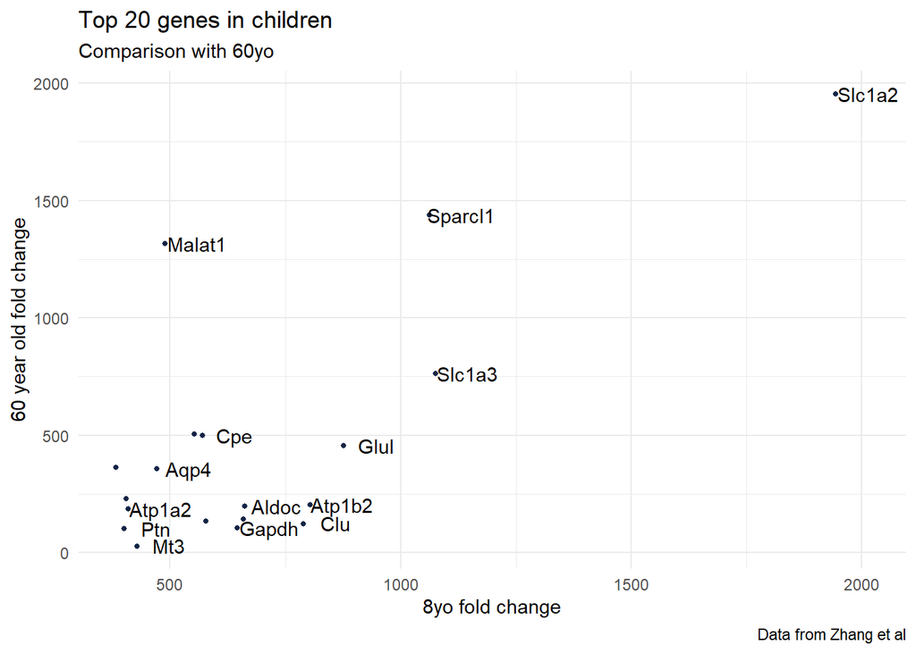

This logic can be extended to the entire dataset, to get an idea of the shape of the data and the outliers of interest

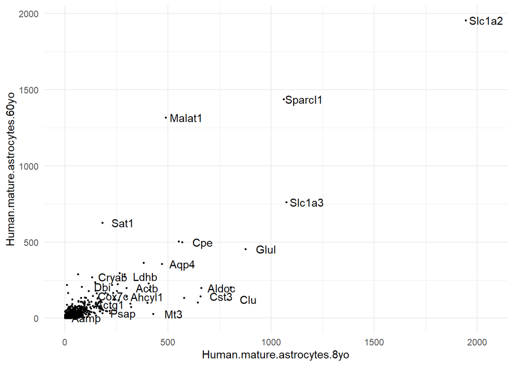

**Picking out genes of interest**

Some potential candidates based on this plot appear to be Malat1 and Spacl1 for elevated. Atp1b2, Clu for reduced. To confirm this I mutated a column of the original dataset with the proportion between old and young fold change, the further from 1 the value is the greater the change. I then output the ten genes with greatest increases and decreases in fold change.

```r
combined_astros_prop <- combined_astros %>%
  mutate(sixty_over_eight = Human.mature.astrocytes.60yo/Human.mature.astrocytes.8yo)

high_in_old <- combined_astros_prop %>%
  arrange(sixty_over_eight) %>%
  slice(0:10)
high_in_old$Gene
```

```
##  [1] "Hist1h1e" "Gng3"     "Fam59a"   "Hdlbp"    "Guk1"     "Sec22c"
##  [7] "Ndufa3"   "Rbm42"    "Mtx1"     "Tmem189"
```

```r
high_in_young <- combined_astros_prop %>%
  arrange(desc(sixty_over_eight)) %>%
  slice(0:10)
high_in_young$Gene
```

```
##  [1] "Cxcl1"  "Cxcl3"  "Asb3"   "Atf3"   "Sarnp"  "Rwdd3"  "Sik1"   "Gfra1"
##  [9] "Nr4a2"  "Tceal7"
```

I noticed that this table is revealing genes not shown on the above trend plot, and that the highest proportional fold changes are in much lower expression genes. Therefore, I decided to do another plot, this time filtering for genes of lower expression, and again for much lower expression. In these plots, I marked in blue any genes with less than a 100% increase or 50% decrease in fold change between ages

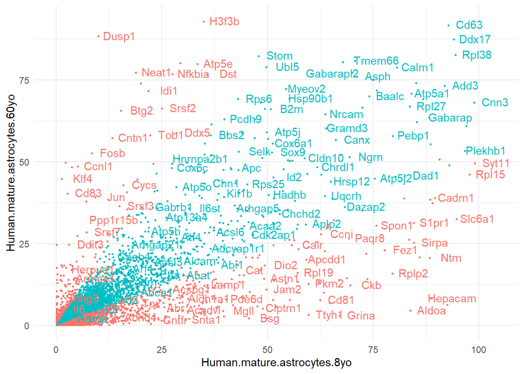

```r
combined_astros_small <- combined_astros_prop %>%
  filter(!(Human.mature.astrocytes.60yo > 100 | Human.mature.astrocytes.8yo > 100))

ggplot(combined_astros_small) +
 aes(x = Human.mature.astrocytes.8yo, y = Human.mature.astrocytes.60yo, color = ifelse(
   !(sixty_over_eight < 0.5 | sixty_over_eight > 2),
  'Similar',
   'Different'
 )) +
 geom_point(shape = "circle", size = 0.5) +
 theme_minimal() +
 geom_text(
    label = combined_astros_small$Gene,
    nudge_x = 5, nudge_y =0.25,
    check_overlap = T
 ) +
  theme(legend.position = "none")
```

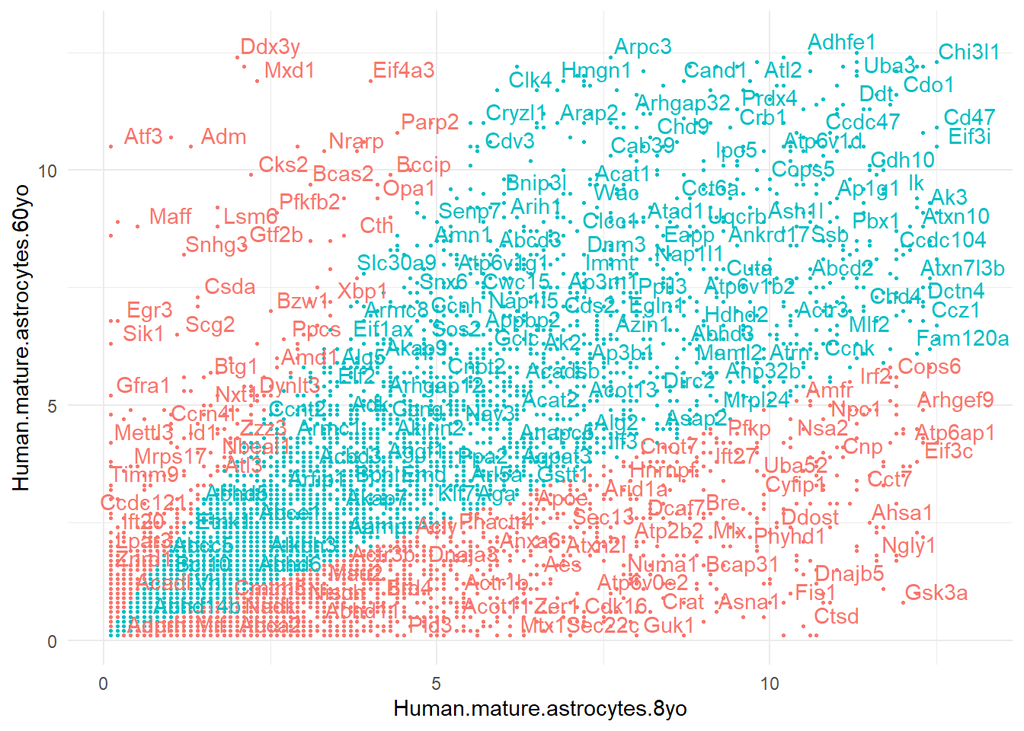

```r
combined_astros_smaller <- combined_astros_prop %>%
  filter(!(Human.mature.astrocytes.60yo > 12.5 | Human.mature.astrocytes.8yo > 12.5))

ggplot(combined_astros_smaller) +
 aes(x = Human.mature.astrocytes.8yo, y = Human.mature.astrocytes.60yo, color = ifelse(
   !(sixty_over_eight < 0.5 | sixty_over_eight > 2),
  'Similar',
   'Different'
 )) +
 geom_point(shape = "circle", size = 0.5) +
 theme_minimal() +
 geom_text(
    label = combined_astros_smaller$Gene,
    nudge_x = 0.5, nudge_y =0.25,
    check_overlap = T
 )+
  theme(legend.position = "none")
```

This graphic is useful, but a bit overwhelming, so I took my lists of the top 10 increasing and decreasing genes and joined them with rbind(), transposed the table, and plotted the data as a line chart. The numbers on the x axis of the line chart each correspond to a categorical age variable from the original dataset, with the key printed below

**Plotting**

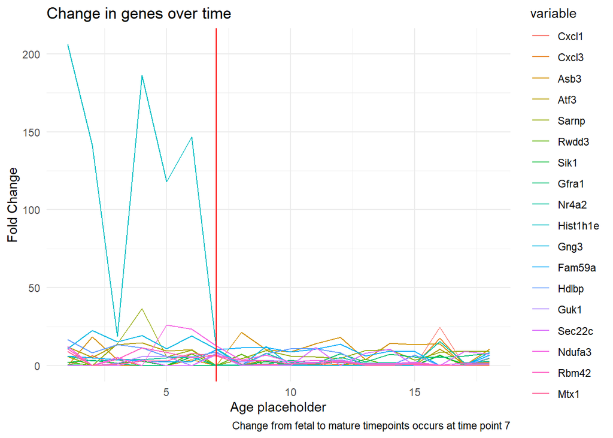

```r
#clean up the data by removing the unneeded columns
top_20_clean <- top_20_transpose %>%
  select(Age_placeholder:Mtx1)

#melt the data frame to make the chart work using the reshape package
df.melted <- melt(top_20_clean, id = 'Age_placeholder')

ggplot(df.melted) +
 aes(Age_placeholder, y = value, color = variable) +
 geom_line() +
 labs(x = 'Age placeholder', y = 'Fold Change', title = "Change in genes over time", caption = "Change from fetal to mature timepoints occurs at time point 7") +
 theme_minimal() +
  geom_vline(xintercept = 7, color = 'red')
```

**Key**

```
##      ï..Age Age_placeholder
## 1    18gw-1               1
## 2    18gw-2               2
## 3  18.5gw-1               3
## 4    18.1gw               4
## 5  18.5gw-2               5
## 6  18.5gw-3               6
## 7       8yo               7
## 8      13yo               8
## 9      16yo               9
## 10     21yo              10
## 11     22yo              11
## 12     35yo              12
## 13     47yo              13
## 14     51yo              14
## 15     53yo              15
## 16     60yo              16
## 17   63yo-1              17
## 18   63yo-2              18
```

This shows that the histone marker Hist1h1e shows a massive decrease in expression after birth which is exciting! however the effect is so strong it is masking our other data so I will filter it out and replot

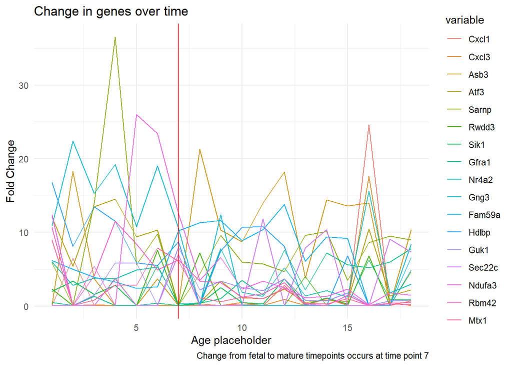

```r
ggplot(df.melted %>% filter(variable != 'Hist1h1e')) +
 aes(Age_placeholder, y = value, color = variable) +
 geom_line() +
 labs(x = 'Age placeholder', y = 'Fold Change', title = "Change in genes over time", caption = "Change from fetal to mature timepoints occurs at time point 7") +
 theme_minimal() +
  geom_vline(xintercept = 7, color = 'red')
```

#### `Conclusions`

Despite being extremely highly expressed in utero, Hist1H1e expression is severely downregulated after birth

Additionally, while genes that decrease with age tend to slowly taper, many of the genes which increase with age show a large spike at ~60 yo

#### `Immediate Follow Up Studies`

I would like to investigate the role of Hist1H1e in astrocyte development by doing a knockout-gene study

I would like to further investigate why these genes spike specifically in old age, it is odd for such a punctate shift at 60 yo, but the effect was either not seen or severely reduced in the 2 63yo cohorts

### `Aknowledgements`

I’d like to thank the Barres lab and their collaborators, particularly the Zhang lab for providing the Brain RNAseq database.  
I’d also like to thank Dr Hirschey and all teaching assistants for their help with the course.